# ML Mini Project

# Plot bar graph of the total no of disputes by State with Maximum Disputes

```python
State_dispute= df_train[df_train['Consumer disputed?']=='Yes'].groupby('State')['Consumer disputed?'].value_counts()
State_dispute=State_dispute.sort_values(ascending = False)
State_dispute
```

```
State  Consumer disputed?
CA     Yes                   12217
FL     Yes                    7152
TX     Yes                    5262
NY     Yes                    5001
GA     Yes                    3302
                             ...
MH     Yes                       3
MP     Yes                       3
AS     Yes                       3
PW     Yes                       3
AA     Yes                       3
Name: Consumer disputed?, Length: 62, dtype: int64
```

```python
State_dispute.index.to_list()
```

```
[('CA', 'Yes'),
 ('FL', 'Yes'),
 ('TX', 'Yes'),
 ('NY', 'Yes'),
 ('GA', 'Yes'),
 ('NJ', 'Yes'),
 ('IL', 'Yes'),
 ('VA', 'Yes'),
 ('PA', 'Yes'),
 ('MD', 'Yes'),
 ('OH', 'Yes'),
 ('NC', 'Yes'),
 ('MI', 'Yes'),
 ('AZ', 'Yes'),
 ('WA', 'Yes'),
 ('MA', 'Yes'),
 ('CO', 'Yes'),
 ('TN', 'Yes'),
 ('NV', 'Yes'),
 ('MO', 'Yes'),
 ('OR', 'Yes'),
 ('MN', 'Yes'),
 ('SC', 'Yes'),
 ('CT', 'Yes'),
 ('WI', 'Yes'),
 ('AL', 'Yes'),
 ('IN', 'Yes'),
 ('LA', 'Yes'),
 ('KY', 'Yes'),
 ('OK', 'Yes'),
 ('DE', 'Yes'),
 ('DC', 'Yes'),
 ('UT', 'Yes'),
 ('MS', 'Yes'),
 ('NH', 'Yes'),
 ('KS', 'Yes'),
 ('NM', 'Yes'),
 ('AR', 'Yes'),
 ('HI', 'Yes'),
 ('ME', 'Yes'),
 ('RI', 'Yes'),
 ('ID', 'Yes'),
 ('IA', 'Yes'),
 ('NE', 'Yes'),
 ('WV', 'Yes'),
 ('PR', 'Yes'),
 ('VT', 'Yes'),
 ('MT', 'Yes'),
 ('AK', 'Yes'),
 ('SD', 'Yes'),
 ('WY', 'Yes'),
 ('ND', 'Yes'),
 ('AP', 'Yes'),
 ('VI', 'Yes'),
 ('AE', 'Yes'),
 ('GU', 'Yes'),
 ('FM', 'Yes'),
 ('MH', 'Yes'),
 ('MP', 'Yes'),
 ('AS', 'Yes'),
 ('PW', 'Yes'),
 ('AA', 'Yes')]
```

```python
State_label = []
for i in State_dispute.index.to_list():
    State_label.append(i[0])
```

```python
State_label
```

```
['CA',
 'FL',
 'TX',
 'NY',
 'GA',
 'NJ',
 'IL',
 'VA',
 'PA',
 'MD',
 'OH',
 'NC',
 'MI',
 'AZ',
 'WA',
 'MA',
 'CO',
 'TN',
 'NV',
 'MO',
 'OR',
 'MN',
 'SC',
 'CT',
 'WI',
 'AL',
 'IN',
 'LA',
 'KY',
 'OK',
 'DE',
 'DC',
 'UT',
 'MS',
 'NH',
 'KS',
 'NM',
 'AR',
 'HI',
 'ME',
 'RI',
 'ID',
 'IA',
 'NE',
 'WV',
 'PR',
 'VT',
 'MT',
 'AK',
 'SD',
 'WY',
 'ND',
 'AP',
 'VI',
 'AE',
 'GU',
 'FM',
 'MH',
 'MP',
 'AS',
 'PW',
 'AA']
```

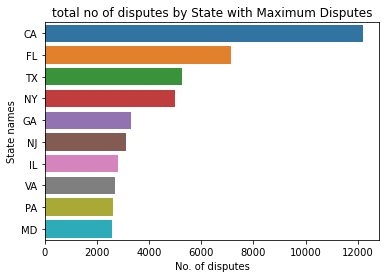

```python
plt.figure()
sns.barplot(x=State_dispute.values[:10] , y= State_label[:10])
plt.xlabel('No. of disputes')
plt.ylabel('State names')
plt.title('total no of disputes by State with Maximum Disputes')
plt.show()
```

# Plot bar graph of the total no of disputes Submitted Via different source

```python
df_train.columns
```

```
Index(['Product', 'Issue', 'Company', 'State', 'Submitted via',
       'Company response to consumer', 'Timely response?',
       'Consumer disputed?', 'Month', 'Year', 'Day', 'Days held',
       'Week_Received'],
      dtype='object')
```

```python
df_train['Submitted via'].value_counts()
```

```
Web            235462
Referral        68450
Phone           25802
Postal mail     23644
Fax              5264
Email             188
Name: Submitted via, dtype: int64
```

```python
Sub_dispute= df_train[df_train['Consumer disputed?']=='Yes'].groupby('Submitted via')['Consumer disputed?'].value_counts()
Sub_dispute
```

```
Submitted via  Consumer disputed?
Email          Yes                      35
Fax            Yes                    1117
Phone          Yes                    4456
Postal mail    Yes                    3497
Referral       Yes                   12066
Web            Yes                   55001
Name: Consumer disputed?, dtype: int64
```

```python
Sub_dispute.index.to_list()
```

```
[('Email', 'Yes'),
 ('Fax', 'Yes'),
 ('Phone', 'Yes'),
 ('Postal mail', 'Yes'),
 ('Referral', 'Yes'),
 ('Web', 'Yes')]
```

```python
sub_label=[]
for i in Sub_dispute.index.to_list():
    sub_label.append(i[0])
```

```python
sub_label
```

```
['Email', 'Fax', 'Phone', 'Postal mail', 'Referral', 'Web']
```

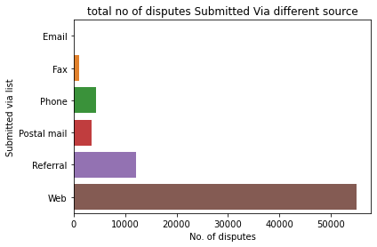

```python
plt.figure()
sns.barplot(x=Sub_dispute.values , y= sub_label)
plt.xlabel('No. of disputes')
plt.ylabel('Submitted via list')
plt.title('total no of disputes Submitted Via different source')
plt.show()
```

# Plot bar graph of the total no of disputes where the Company's Response to the Complaints

```python
Complaint_dispute = df_train[df_train['Consumer disputed?']=='Yes'].groupby('Timely response?')['Consumer disputed?'].value_counts()
Complaint_dispute=Complaint_dispute.sort_values(ascending = False)
Complaint_dispute
```

```
Timely response?  Consumer disputed?
Yes               Yes                   74943
No                Yes                    1229
Name: Consumer disputed?, dtype: int64
```

```python
Complaint_dispute.index.to_list()
```

```
[('Yes', 'Yes'), ('No', 'Yes')]
```

```python
Complaint_label=[]
for i in Complaint_dispute.index.to_list():
    Complaint_label.append(i[0])
```

```python
Complaint_label
```

```
['Yes', 'No']
```

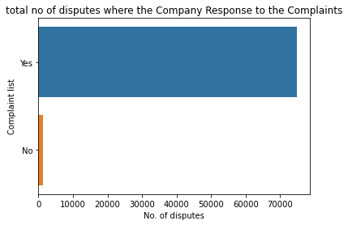

```python
plt.figure()
sns.barplot(x=Complaint_dispute.values , y= Complaint_label)
plt.xlabel('No. of disputes')
plt.ylabel('Complaint list')
plt.title('total no of disputes where the Company Response to the Complaints')
plt.show()
```

# Plot bar graph of the total no of disputes where the Company's Response Leads to Disputes

```python
Response_dispute = df_train[df_train['Consumer disputed?']=='Yes'].groupby('Company response to consumer')['Consumer disputed?'].value_counts()
Response_dispute=Response_dispute.sort_values(ascending = False)
Response_dispute
```

```
Company response to consumer     Consumer disputed?
Closed with explanation          Yes                   62108
Closed with non-monetary relief  Yes                    5987
Closed with monetary relief      Yes                    2864
Closed without relief            Yes                    2859
Closed                           Yes                    1928
Closed with relief               Yes                     426
Name: Consumer disputed?, dtype: int64
```

```python
Response_dispute.index.to_list()
```

```
[('Closed with explanation', 'Yes'),
 ('Closed with non-monetary relief', 'Yes'),
 ('Closed with monetary relief', 'Yes'),
 ('Closed without relief', 'Yes'),
 ('Closed', 'Yes'),
 ('Closed with relief', 'Yes')]
```

```python
response_label=[]
for i in Response_dispute.index.to_list():
    response_label.append(i[0])
```

```python
response_label
```

```
['Closed with explanation',
 'Closed with non-monetary relief',
 'Closed with monetary relief',
 'Closed without relief',
 'Closed',
 'Closed with relief']
```

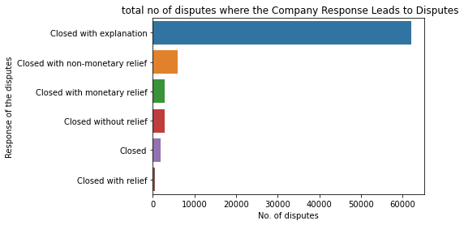

```python
plt.figure()
sns.barplot(x=Response_dispute.values , y=response_label)
plt.xlabel('No. of disputes')
plt.ylabel('Response of the disputes')
plt.title(' total no of disputes where the Company Response Leads to Disputes')
plt.show()
```

# Plot bar graph of the total no of disputes over Year Wise Complaints

```python
year_complaint = df_train[df_train['Consumer disputed?']=='Yes'].groupby(['Year','Issue'])['Consumer disputed?'].value_counts()
year_complaint=year_complaint.sort_values(ascending = False)
year_complaint
```

```
Year  Issue                                     Consumer disputed?
2013  Loan modification,collection,foreclosure  Yes                   3791
2012  Loan modification,collection,foreclosure  Yes                   3240
2014  Loan modification,collection,foreclosure  Yes                   2935
2015  Loan modification,collection,foreclosure  Yes                   2600
      Loan servicing, payments, escrow account  Yes                   2362
                                                                      ...
2011  Overlimit fee                             Yes                      1
      Privacy                                   Yes                      1
2016  Advertising, marketing or disclosures     Yes                      1
2014  Repaying your loan                        Yes                      1
2013  Payment to acct not credited              Yes                      1
Name: Consumer disputed?, Length: 423, dtype: int64
```

```python
year_complaint.index.to_list()
```

```
[(2013, 'Loan modification,collection,foreclosure', 'Yes'),
 (2012, 'Loan modification,collection,foreclosure', 'Yes'),
 (2014, 'Loan modification,collection,foreclosure', 'Yes'),
 (2015, 'Loan modification,collection,foreclosure', 'Yes'),
 (2015, 'Loan servicing, payments, escrow account', 'Yes'),
 (2015, 'Incorrect information on credit report', 'Yes'),
 (2014, 'Loan servicing, payments, escrow account', 'Yes'),
 (2015, "Cont'd attempts collect debt not owed", 'Yes'),
 (2013, 'Loan servicing, payments, escrow account', 'Yes'),
 (2014, 'Incorrect information on credit report', 'Yes'),
 (2016, 'Incorrect information on credit report', 'Yes'),
 (2014, "Cont'd attempts collect debt not owed", 'Yes'),
 (2016, 'Loan servicing, payments, escrow account', 'Yes'),
 (2012, 'Loan servicing, payments, escrow account', 'Yes'),
 (2016, 'Loan modification,collection,foreclosure', 'Yes'),
 (2016, "Cont'd attempts collect debt not owed", 'Yes'),
 (2015, 'Disclosure verification of debt', 'Yes'),
 (2013, 'Incorrect information on credit report', 'Yes'),
 (2015, 'Account opening, closing, or management', 'Yes'),
 (2014, 'Disclosure verification of debt', 'Yes'),
 (2014, 'Account opening, closing, or management', 'Yes'),
 (2016, 'Disclosure verification of debt', 'Yes'),
 (2013, 'Account opening, closing, or management', 'Yes'),
 (2016, 'Account opening, closing, or management', 'Yes'),
 (2015, "Credit reporting company's investigation", 'Yes'),
 (2012, 'Account opening, closing, or management', 'Yes'),
 (2014, 'Communication tactics', 'Yes'),
 (2013, 'Application, originator, mortgage broker', 'Yes'),
 (2015, 'Application, originator, mortgage broker', 'Yes'),
 (2015, 'Communication tactics', 'Yes'),
 (2015, 'Deposits and withdrawals', 'Yes'),
 (2016, 'Dealing with my lender or servicer', 'Yes'),
 (2016, "Credit reporting company's investigation", 'Yes'),
 (2015, 'Managing the loan or lease', 'Yes'),
 (2013, "Cont'd attempts collect debt not owed", 'Yes'),
 (2012, 'Deposits and withdrawals', 'Yes'),
 (2013, 'Deposits and withdrawals', 'Yes'),
 (2012, 'Application, originator, mortgage broker', 'Yes'),
 (2014, 'Deposits and withdrawals', 'Yes'),
 (2015, 'False statements or representation', 'Yes'),
```

[output cut: 368 more lines]

```
 (2013, 'Applied for loan/did not receive money', 'Yes'),
 (2015, 'Overdraft, savings or rewards features', 'Yes'),
 (2016, 'Lost or stolen check', 'Yes'),
 (2016, 'Convenience checks', 'Yes'),
 (2014, 'Lender damaged or destroyed property', 'Yes'),
 (2011, 'Late fee', 'Yes'),
 (2013, 'Incorrect/missing disclosures or info', 'Yes'),
 (2013, 'Overlimit fee', 'Yes'),
 (2016, 'Disclosures', 'Yes'),
 (2011, 'Other fee', 'Yes'),
 (2011, 'Overlimit fee', 'Yes'),
 (2011, 'Privacy', 'Yes'),
 (2016, 'Advertising, marketing or disclosures', 'Yes'),
 (2014, 'Repaying your loan', 'Yes'),
 (2013, 'Payment to acct not credited', 'Yes')]
```

```python
issue_complaint=[]
for i in year_complaint.index.to_list():
    issue_complaint.append(i[0])
```

```python
issue_complaint
```

```
[2013,
 2012,
 2014,
 2015,
 2015,
 2015,
 2014,
 2015,
 2013,
 2014,
 2016,
 2014,
 2016,
 2012,
 2016,
 2016,
 2015,
 2013,
 2015,
 2014,
 2014,
 2016,
 2013,
 2016,
 2015,
 2012,
 2014,
 2013,
 2015,
 2015,
 2015,
 2016,
 2016,
 2015,
 2013,
 2012,
 2013,
 2012,
 2014,
 2015,
```

[output cut: 368 more lines]

```
 2013,
 2015,
 2016,
 2016,
 2014,
 2011,
 2013,
 2013,
 2016,
 2011,
 2011,
 2011,
 2016,
 2014,
 2013]
```

[figure not shown]

```python
plt.figure()
sns.barplot(x=year_complaint.values[:10] , y=issue_complaint[:10])
plt.xlabel('No. of disputes')
plt.ylabel('Year wise complaint')
plt.title(' the total no of disputes over Year Wise Complaints')
plt.xticks(rotation=90)
plt.show()
```